# 5 Dimensionality Reduction Techniques

## 5.3. Principal Component Analysis on the not standardized human data

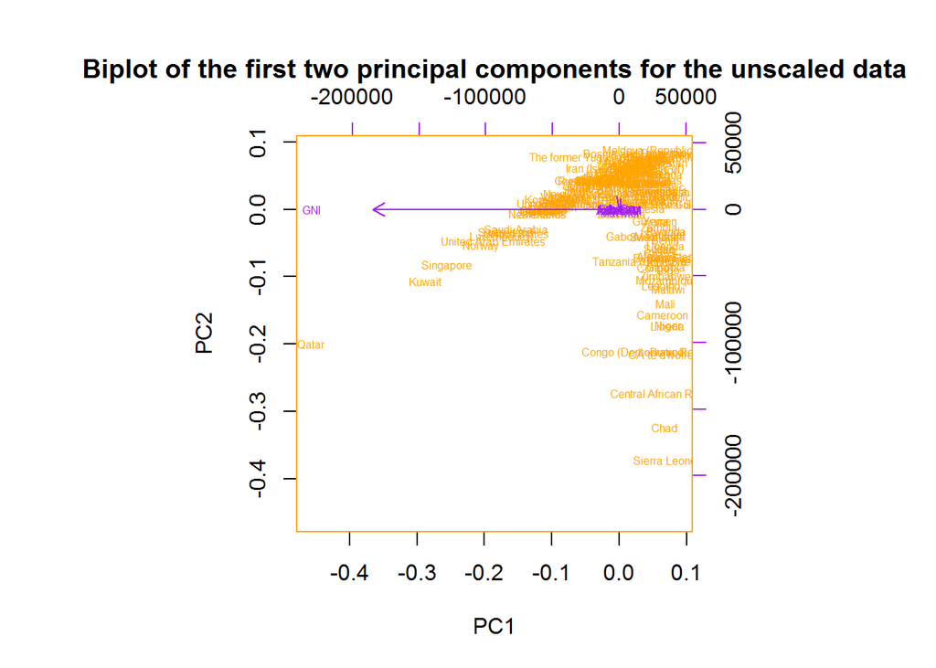

```r
pca_human <- prcomp(human)
biplot(pca_human, choices = 1:2, cex = c(0.5,0.5), col = c("orange", "purple"), main="Biplot of the first two principal components for the unscaled data")
```

*Only GNI is visible* Correlation is negligible *High variance* Qatar seems to be outlier

## 5.4 Principal Component Analysis on the Standardized human data

**Lets scale the data for better interpretation

```r
human_scale <- scale(human)
summary(human_scale)
```

```
##     Edu2.FM           Labo.FM           Edu.Exp           Life.Exp
##  Min.   :-2.8189   Min.   :-2.6247   Min.   :-2.7378   Min.   :-2.7188
##  1st Qu.:-0.5233   1st Qu.:-0.5484   1st Qu.:-0.6782   1st Qu.:-0.6425
##  Median : 0.3503   Median : 0.2316   Median : 0.1140   Median : 0.3056
##  Mean   : 0.0000   Mean   : 0.0000   Mean   : 0.0000   Mean   : 0.0000
##  3rd Qu.: 0.5958   3rd Qu.: 0.7350   3rd Qu.: 0.7126   3rd Qu.: 0.6717
##  Max.   : 2.6646   Max.   : 1.6632   Max.   : 2.4730   Max.   : 1.4218
##       GNI             Mat.Mor          Ado.Birth          Parli.F
##  Min.   :-0.9193   Min.   :-0.6992   Min.   :-1.1325   Min.   :-1.8203
##  1st Qu.:-0.7243   1st Qu.:-0.6496   1st Qu.:-0.8394   1st Qu.:-0.7409
##  Median :-0.3013   Median :-0.4726   Median :-0.3298   Median :-0.1403
##  Mean   : 0.0000   Mean   : 0.0000   Mean   : 0.0000   Mean   : 0.0000
##  3rd Qu.: 0.3712   3rd Qu.: 0.1932   3rd Qu.: 0.6030   3rd Qu.: 0.6127
##  Max.   : 5.6890   Max.   : 4.4899   Max.   : 3.8344   Max.   : 3.1850
```

```r
summary(human)
```

```
##     Edu2.FM          Labo.FM          Edu.Exp         Life.Exp
##  Min.   :0.1717   Min.   :0.1857   Min.   : 5.40   Min.   :49.00
##  1st Qu.:0.7264   1st Qu.:0.5984   1st Qu.:11.25   1st Qu.:66.30
##  Median :0.9375   Median :0.7535   Median :13.50   Median :74.20
##  Mean   :0.8529   Mean   :0.7074   Mean   :13.18   Mean   :71.65
##  3rd Qu.:0.9968   3rd Qu.:0.8535   3rd Qu.:15.20   3rd Qu.:77.25
##  Max.   :1.4967   Max.   :1.0380   Max.   :20.20   Max.   :83.50
##       GNI            Mat.Mor         Ado.Birth         Parli.F
##  Min.   :   581   Min.   :   1.0   Min.   :  0.60   Min.   : 0.00
##  1st Qu.:  4198   1st Qu.:  11.5   1st Qu.: 12.65   1st Qu.:12.40
##  Median : 12040   Median :  49.0   Median : 33.60   Median :19.30
##  Mean   : 17628   Mean   : 149.1   Mean   : 47.16   Mean   :20.91
##  3rd Qu.: 24512   3rd Qu.: 190.0   3rd Qu.: 71.95   3rd Qu.:27.95
##  Max.   :123124   Max.   :1100.0   Max.   :204.80   Max.   :57.50
```

**Check PCA after scaling

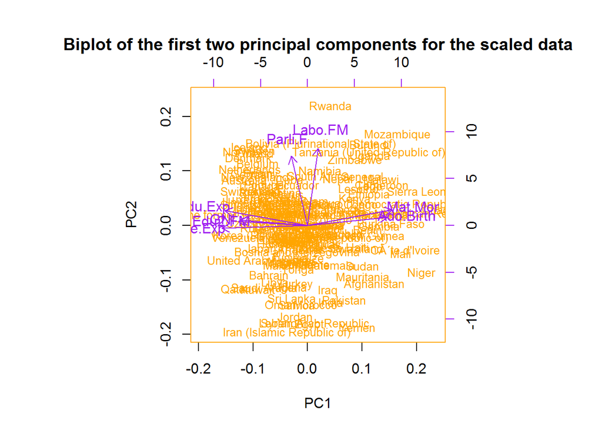

```r
pca_human <- prcomp(human_scale)
biplot(pca_human, choices = 1:2, cex = c(0.8, 1), col = c("orange", "purple"), main="Biplot of the first two principal components for the scaled data")
```

Distribution of Countries explains the individual records. Data is now normalized with different parameters. Countries are now separated with respect to correlations with Principal Components

## 5.6. Multiple Correspondence Analysis (MCA)

In the case of categorical variables dimensionality reduction can be provided using correspondence analysis (CA, n=2 variables) or multiple corresponding analysis (MCA, n>2). MCA is a generalization of PCA and an extension of CA. In this analysis cross tabulation matrices between all variables in the data set are used. The information from cross-tabulations has to be presented in clear graphical form. MCA could be used for example as a pre-processing for clustering.

### 5.4.1 The data

Here we use tea data from FactoMineR package.

```r
library(FactoMineR)
```

```r
library(tidyr)
library(ggplot2)
library(dplyr)
data("tea")
keep_columns <- c("Tea","price","How", "how", "sugar", "where","lunch")
tea_time <- dplyr::select(tea, one_of(keep_columns))
summary(tea_time)
```

```
##         Tea                  price        How
##  black    : 74   p_branded      : 95   alone:195
##  Earl Grey:193   p_cheap        :  7   lemon: 33
##  green    : 33   p_private label: 21   milk : 63
##                  p_unknown      : 12   other:  9
##                  p_upscale      : 53
##                  p_variable     :112
##                  how           sugar                      where
##  tea bag           :170   No.sugar:155   chain store         :192
##  tea bag+unpackaged: 94   sugar   :145   chain store+tea shop: 78
##  unpackaged        : 36                  tea shop            : 30
##
##
##
##        lunch
##  lunch    : 44
##  Not.lunch:256
##
##
##
##
```

```r
str(tea_time)
```

```
## 'data.frame':    300 obs. of  7 variables:
##  $ Tea  : Factor w/ 3 levels "black","Earl Grey",..: 1 1 2 2 2 2 2 1 2 1 ...
##  $ price: Factor w/ 6 levels "p_branded","p_cheap",..: 4 6 6 6 6 3 6 6 5 5 ...
##  $ How  : Factor w/ 4 levels "alone","lemon",..: 1 3 1 1 1 1 1 3 3 1 ...
##  $ how  : Factor w/ 3 levels "tea bag","tea bag+unpackaged",..: 1 1 1 1 1 1 1 1 2 2 ...
##  $ sugar: Factor w/ 2 levels "No.sugar","sugar": 2 1 1 2 1 1 1 1 1 1 ...
##  $ where: Factor w/ 3 levels "chain store",..: 1 1 1 1 1 1 1 1 2 2 ...
##  $ lunch: Factor w/ 2 levels "lunch","Not.lunch": 2 2 2 2 2 2 2 2 2 2 ...
```

Selected Parameters : Tea, price, How, how, sugar, where and lunch.

Graphically the date are presented as barplots using ggplot() function.

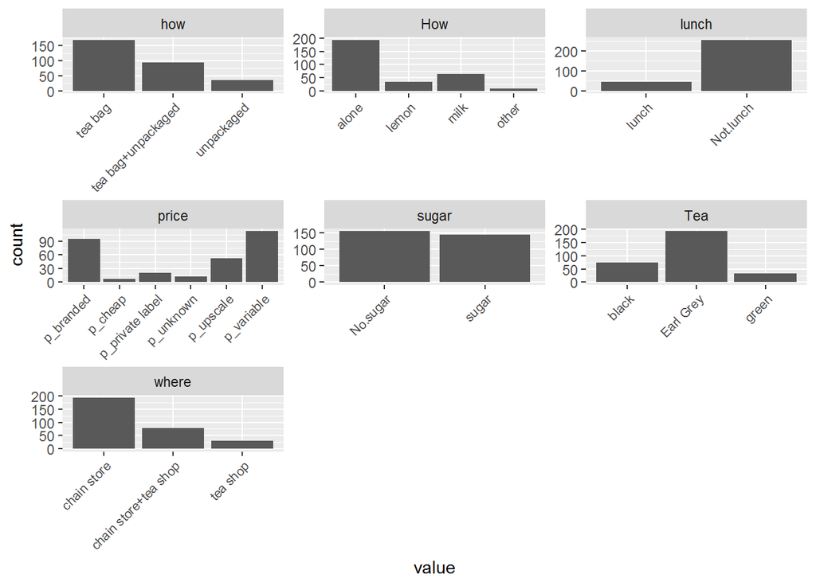

```r
gather(tea_time) %>% ggplot(aes(value)) + facet_wrap("key", scales = "free") + geom_bar()+theme(axis.text.x = element_text(angle = 45, hjust = 1, size = 8))
```

* Very Few peope drink Cheap tea. * Most people drink tea alone with tea bags and preferred tea variety is Earl Grey at Chain Shops.

Next MCA analysis on the chosen tea data is provided.

```r
mca <- MCA(tea_time, graph = FALSE)
summary(mca)
```

```
##
## Call:
## MCA(X = tea_time, graph = FALSE)
##
##
## Eigenvalues
##                        Dim.1   Dim.2   Dim.3   Dim.4   Dim.5   Dim.6
## Variance               0.304   0.249   0.188   0.180   0.156   0.152
## % of var.             13.293  10.896   8.242   7.858   6.846   6.632
## Cumulative % of var.  13.293  24.189  32.431  40.289  47.136  53.767
##                        Dim.7   Dim.8   Dim.9  Dim.10  Dim.11  Dim.12
## Variance               0.148   0.140   0.130   0.124   0.118   0.101
## % of var.              6.463   6.128   5.691   5.441   5.151   4.428
## Cumulative % of var.  60.230  66.358  72.049  77.490  82.641  87.069
##                       Dim.13  Dim.14  Dim.15  Dim.16
## Variance               0.095   0.080   0.073   0.048
## % of var.              4.169   3.479   3.193   2.090
## Cumulative % of var.  91.238  94.717  97.910 100.000
##
## Individuals (the 10 first)
##                    Dim.1    ctr   cos2    Dim.2    ctr   cos2    Dim.3
## 1               | -0.466  0.238  0.050 |  0.477  0.305  0.053 | -0.312
## 2               | -0.192  0.040  0.024 | -0.024  0.001  0.000 | -0.633
## 3               | -0.293  0.094  0.116 | -0.032  0.001  0.001 | -0.142
## 4               | -0.410  0.185  0.221 | -0.003  0.000  0.000 |  0.228
## 5               | -0.293  0.094  0.116 | -0.032  0.001  0.001 | -0.142
## 6               | -0.486  0.260  0.099 |  0.348  0.162  0.050 | -0.096
## 7               | -0.293  0.094  0.116 | -0.032  0.001  0.001 | -0.142
## 8               | -0.192  0.040  0.024 | -0.024  0.001  0.000 | -0.633
## 9               |  0.569  0.356  0.150 | -0.552  0.407  0.141 | -0.121
## 10              |  0.812  0.723  0.321 | -0.401  0.216  0.078 | -0.636
##                    ctr   cos2
## 1                0.172  0.023 |
## 2                0.708  0.256 |
## 3                0.036  0.027 |
## 4                0.092  0.068 |
## 5                0.036  0.027 |
## 6                0.016  0.004 |
## 7                0.036  0.027 |
## 8                0.708  0.256 |
```

[output cut: 21 more lines]

```
## p_private label   0.024   2.658 |   0.206   0.226   0.003   0.978 |
## p_unknown         0.017   2.241 |  -0.047   0.007   0.000  -0.165 |
## p_upscale         0.048   3.777 |  -0.038   0.019   0.000  -0.305 |
## p_variable        0.351 -10.246 |   0.066   0.124   0.003   0.884 |
## alone             0.040   3.447 |  -0.077   0.289   0.011  -1.804 |
##
## Categorical variables (eta2)
##                   Dim.1 Dim.2 Dim.3
## Tea             | 0.090 0.104 0.416 |
## price           | 0.612 0.354 0.009 |
## How             | 0.055 0.087 0.392 |
## how             | 0.619 0.492 0.013 |
## sugar           | 0.051 0.003 0.316 |
## where           | 0.700 0.604 0.059 |
## lunch           | 0.000 0.099 0.114 |
```

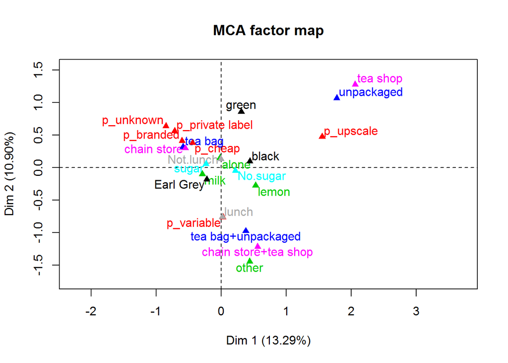

```r
plot(mca, invisible=c("ind"), habillage = "quali")
```

- Tea Shop usually has unpackaged tea with high prices (p_upscale)
- People usually have Earl Gray and more likely to have it with sugar and milk.
- Green Tea is cut from all..(Explains a lot)